# Assignment 4

Daniele Monterisi

4/6/2020

## Introduction

DM Systems has agreed to supply 500,000 Voip Phones to DISCO Stores in 90 days at fixed price. A key component in the phones is a programmable array logic integrated circuit chip (“PAL chip”), one of which is required in each phone. DM Systems has bought these chips in the past from an Italian chip manufacturer, IM Chips. However, DM Systems has been approached by a Korean manufacturer, KR Electronics, which is offering a lower price on the chips. This offer is open for only 10 days, and DM Systems must decide whether to buy some or all of the PAL chips from KR. Any chips that DM does not buy from KR will be bought from IM. IM Chips will sell PAL chips to DM for $3.00 per chip in any quantity. KR will accept orders only in multiples of 250,000 PAL chips, and is offering to sell the chips for $2.00 per chip for 250,000 chips, and for $1.50 per chip in quantities of 500,000 or more chips.

## The dumping charge

The situation is complicated by a dumping charge that has been filed by IM Chips against KR. If this charge is upheld by the Italian government, then the KR chips will be subject to an antidumping tax. This case will not be resolved until after the point in time when DM must make the purchase decision. If DM buys the KR chips, these will not be shipped until after the antidumping tax would go into effect and the chips would be subject to the tax. Under the terms offered by KR, DM would have to pay any antidumping tax that is imposed. DM believes there is a 60% chance the antidumping tax will be imposed. If it is imposed, then it is equally likely that the tax will be 50%, 100%, or 200% of the sale price for each PAL chip.

## The decision tree

Draw a decision tree for this decision

- Install packages

```r
#install.packages("yaml")
#install.packages("radiant")
#install.packages("radiant.model")
```

```r
library(yaml)
library(radiant)
library(radiant.model)
```

Importing the tree (.yaml)

```r
first_tree = yaml.load_file(input = "C:\\Users\\Daniele\\Desktop\\Assignment 4\\first_tree.yaml")
result = dtree(yl = first_tree)
plot(result, final = FALSE)
```

[interactive chart not shown]

## Expected value

```r
plot(result, final = TRUE)
```

[interactive chart not shown]

## Sensitivity analysis

```r
sensitivity(
  result,
  vars = "p_tax 0 1 0.1;",
  decs = c("FROM_IM", "FROM_IM_KR", "FROM_KR"),
  custom = FALSE
)
```

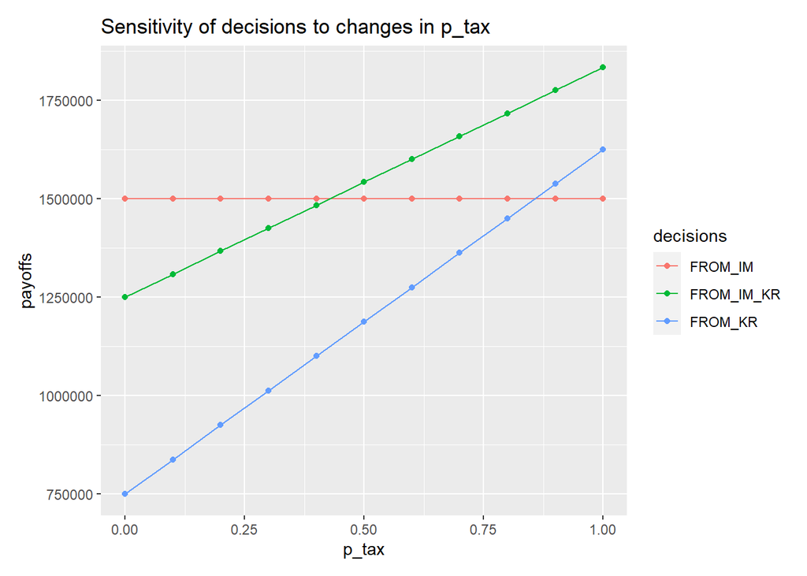

## Utility Function and Certainty Equivalent

```r
utilityFunctionExp <- function(X, R) {
  res <- 1- exp(-X/R)
  return(res)
}

outcomes = c(1500000, 1250000, 1500000, 1750000, 2250000, 750000, 11250000, 1500000, 2250000)
utility = utilityFunctionExp(outcomes, 750000)
all_IM = utility[1]
both = 0.4*utility[2]+0.6*(0.3333*utility[3]+0.3333*utility[4]+0.3333*utility[5])
all_KR = 0.4*utility[6]+0.6*(0.3333*utility[7]+0.3333*utility[8]+0.3333*utility[9])
c(all_IM, both, all_KR)
```

```
## [1] 0.8646647 0.8679765 0.8157674
```

## KR revises the offer

```r
second_tree = yaml.load_file(input ="C:\\Users\\Daniele\\Desktop\\Assignment 4\\second_tree.yaml")
```

```r
result2 = dtree(yl = second_tree)
plot(result2, final = TRUE)
```

[interactive chart not shown]

## Value of Information

```r
third_tree = yaml.load_file(input ="C:\\Users\\Daniele\\Desktop\\Assignment 4\\third_tree.yaml")
```

```r
result3 = dtree(yl = third_tree)
plot(result3, final = TRUE)
```

[interactive chart not shown]